# STOR 455 Homework 2

40 points - Due Wednesday 9/15 at 5:00pm

**Situation:** Suppose that you are interested in purchasing a used car. How much should you expect to pay? Obviously the price will depend on the type of car you get (the model) and how much it’s been used. For this assignment you will investigate how the price might depend on the age and mileage.

**Data Source:** To get a sample of cars, begin with the UsedCars CSV file. The data was acquired by scraping TrueCar.com for used car listings on 9/24/2017 and contains more than 1.2 million used cars. For this assignment you will choose a car *Model* for which there are at least 100 of that model listed for sale in a state of your choice (that is not North Carolina). After constructing a subset of the UsedCars data under these conditions, check to make sure that there is a reasonable amount of variability in the years and mileages for your car (ie, all of your cars are not from the same year). The model that you choose should have cars ranging over at least 5 years. You should add a variable called *Age* which is 2017-year (since the data was scraped in 2017).

**Directions:** The code below should walk you through the process of selecting data from a particular model and state of your choice. Each of the following two R chunks begin with {r, eval=FALSE}. eval=FALSE makes these chunks not run when I knit the file. Before you knit these chunks, you should revert them to {r}.

```r
library(readr)

# This line will only run if the UsedCars.csv is stored in the same directory as this notebook!
UsedCars <- read_csv("UsedCars.csv")
# Delete the ** below and enter the two letter abbreviation for the state of your choice.
StateOfMyChoice = "TX"

# Creates a dataframe with the number of each model for sale in your state
Cars = as.data.frame(table(UsedCars$Model[UsedCars$State==StateOfMyChoice]))

# Renames the variables
names(Cars)[1] = "Model"
names(Cars)[2] = "Count"

# Restricts the data to only models with at least 100 for sale
# Before submitting, comment this out so that it doesn't print while knitting
# Enough_Cars = subset(Cars, Count>=100)
# Enough_Cars
```

```r
# Delete the ** below and enter the model that you chose from the Enough_Cars data.
ModelOfMyChoice = "Accord"

# Takes a subset of your model car from your state
MyCars = subset(UsedCars, Model==ModelOfMyChoice & State==StateOfMyChoice)

# Check to make sure that the cars span at least 5 years.
range(MyCars$Year)
```

```
[1] 1998 2017
```

```r
# Add a new variable for the age of the cars.
MyCars$Age = 2017 - MyCars$Year
```

#### MODEL #1: Use Age as a predictor for Price

1. Calculate the least squares regression line that best fits your data. Interpret (in context) what the slope estimate tells you about prices and ages of your used car model. Explain why the sign (positive/negative) makes sense.

The least squares regression model for a linear regressions model for price on the age of Texas Honda Accords is yhat = -1408.64x + 21571.35. The negative slope makes sense because as the car’s age increases, the price of the car is going to decrease.

```r
mod1 <- lm(Price~Age, MyCars)
summary(lm(Price~Age, MyCars))
```

```
Call:
lm(formula = Price ~ Age, data = MyCars)

Residuals:
    Min      1Q  Median      3Q     Max
-7533.1 -1820.8  -376.3  1423.6 15619.3

Coefficients:
            Estimate Std. Error t value Pr(>|t|)
(Intercept) 21571.35     114.33  188.68   <2e-16 ***
Age         -1408.64      21.92  -64.26   <2e-16 ***
---
Signif. codes:  0 ‘***’ 0.001 ‘**’ 0.01 ‘*’ 0.05 ‘.’ 0.1 ‘ ’ 1

Residual standard error: 2816 on 1375 degrees of freedom
Multiple R-squared:  0.7502,    Adjusted R-squared:   0.75
F-statistic:  4129 on 1 and 1375 DF,  p-value: < 2.2e-16
```

2. Produce a scatterplot of the relationship with the regression line on it.

```r
plot(Price~Age, MyCars)
abline(mod1)
```

[output not shown]

3. Produce appropriate residual plots and comment on how well your data appear to fit the conditions for a linear model. Don’t worry about doing transformations at this point if there are problems with the conditions.

Inspecting the five conditions for a simple linear model: - Linearity: This data does not appear to fit a linear model very well. The data on the residuals vs fitted plot have an obvious left skew with a distinct curved pattern.  
- Zero mean: According to the residual vs fitted plot, the residuals appear to be high on the low end and high on the extreme high end. Between about 7000 and 17000, the data appears to dip. I would say the zero mean condition is met since the residuals still hover around a 0 residual level.  
- COnstant Variance: This model fails to satisfy the constant variance for the simple linear model condition. This is because there is an ovibous pattern to the residuals.  
- Independence: I will assume that each car is independent of each other. - Normality: Looking at the histogram of the residuals, this method appears to have a right skew.

```r
plot(Price~Age, MyCars)
abline(mod1)
```

[output not shown]

```r
plot(mod1, 1:2)
```

[output not shown]

```r
hist(mod1$residuals)
```

[output not shown]

4. Find the car in your sample with the largest residual (in magnitude - positive or negative). For that car, find its standardized and studentized residual. Based on these residuals, could this value be considered influential?

```r
MyCars$residuals <- mod1$residuals
max(MyCars$residuals)
```

```
[1] 15619.29
```

```r
x <- which.max(MyCars$residuals)
MyCars[x,]
```

| Id | Price | Year | Mileage | City | State | Vin | Make | Model | Age | residuals |
| --- | --- | --- | --- | --- | --- | --- | --- | --- | --- | --- |
| 795748 | 35782 | 2016 | 7000 | Odessa | TX | 1HGCT2B03GA004966 | Honda | Accord | 1 | 15619.29 |

```r
min(MyCars$residuals)
```

```
[1] -7533.129
```

```r
y <- which.min(MyCars$residuals)
MyCars[y,]
```

| Id | Price | Year | Mileage | City | State | Vin | Make | Model | Age | residuals |
| --- | --- | --- | --- | --- | --- | --- | --- | --- | --- | --- |
| 382862 | 6995 | 2012 | 201002 | Texarkana | TX | 1HGCP2F85CA111077 | Honda | Accord | 5 | -7533.129 |

Finding the standardized and studentized residual:

```r
rstudent(mod1)[x]
```

```
    1375
5.611175
```

```r
rstandard(mod1)[x]
```

```
    1375
5.549988
```

5. Determine the leverages for the cars with the ten largest absolute residuals. What do these leverage values say about the potential for each of these ten cars to be influential on your model?

Looking at the residuals below, the 10 highest positive residuals are all absolutely greater than the 10 lowest negative residuals, so we will use the positive residuals.

```r
test <- sort(MyCars$residuals, decreasing = TRUE)[1:10]
test # Gives you the row numbers for the highest postive residuals
```

```
     1375      1377       620       594      1352      1290       683      1294      1282      1374
15619.293 14309.582 11736.293 10423.648 10240.937  9690.894  9684.249  9427.648  9316.648  9228.648
```

```r
test2 <- sort(MyCars$residuals, decreasing = FALSE)[1:10]
test2 # Gives you the row numbers for the lowest negative residuals
```

```
      673       185       919       982        73      1006       496       804       463       508
-7533.129 -7131.774 -6895.418 -6533.129 -6350.418 -6228.129 -6106.774 -5941.774 -5722.129 -5537.129
```

```r
test
```

```
     1375      1377       620       594      1352      1290       683      1294      1282      1374
15619.293 14309.582 11736.293 10423.648 10240.937  9690.894  9684.249  9427.648  9316.648  9228.648
```

```r
test2
```

```
      673       185       919       982        73      1006       496       804       463       508
-7533.129 -7131.774 -6895.418 -6533.129 -6350.418 -6228.129 -6106.774 -5941.774 -5722.129 -5537.129
```

The values below calculate the leverage for the high residual values we want to check to see if they are influential.

```r
# mod1[[2]][c(1375,1377,620,594,1352, 1290, 683, 1294, 1282, 1374)]
# The above code just checks to make sure I'm calling the correct values
learning <- hatvalues(mod1)
chosen <- learning[c(1375,1377,620,594,1352, 1290, 683, 1294, 1282, 1374)]
```

The code below compares the chosen hatvalues from mod1 to leverage. The below inequality tells us that values from row 1290 and 683 have high leverage on the model. This tells us that of the 10 highest residuals in our model, only 2 have high leverage on the model.

```r
lowlev <- 2*(2/nrow(MyCars)) # Low Leverage
highlev <- 3*(2/nrow(MyCars)) # High Leverage

# Low leverage
chosen > lowlev
```

```
 1375  1377   620   594  1352  1290   683  1294  1282  1374
FALSE FALSE FALSE FALSE FALSE  TRUE  TRUE FALSE FALSE FALSE
```

```r
chosen > highlev
```

```
 1375  1377   620   594  1352  1290   683  1294  1282  1374
FALSE FALSE FALSE FALSE FALSE  TRUE  TRUE FALSE FALSE FALSE
```

6. Determine the Cook’s distances for the cars with the ten largest absolute residuals. What do these Cook’s distance values say about the influence of each of these ten cars on your model?

```r
cookmod1 <- cooks.distance(mod1)
cookmod1[c(1375,1377,620,594,1352, 1290, 683, 1294, 1282, 1374)]
```

```
       1375        1377         620         594        1352        1290         683        1294        1282        1374
0.019060188 0.010025926 0.010761339 0.011328593 0.006261439 0.088674402 0.077499746 0.009267086 0.009050152 0.008879994
```

```r
cookmod1[c(1375,1377,620,594,1352, 1290, 683, 1294, 1282, 1374)] > 1
```

```
 1375  1377   620   594  1352  1290   683  1294  1282  1374
FALSE FALSE FALSE FALSE FALSE FALSE FALSE FALSE FALSE FALSE
```

7. Compute and interpret in context a 90% confidence interval for the slope of your regression line.

*RESPONSE:* On average, with a 1 year increase in age the price should decrease by 1444.727 to 1372.56 dollars. In other words, we are 90% confident with a 1 year increase in the age of a Texas Honda Accord, the price will decrease somewhere between 1444.72 to 1372.56 dollars.

```r
# Personal Reminder: lm(Price~Age, MyCars)
confint(mod1, level = .90)
```

```
                  5 %      95 %
(Intercept) 21383.177 21759.527
Age         -1444.727 -1372.562
```

8. Test the strength of the linear relationship between your variables using each of the three methods (test for correlation, test for slope, ANOVA for regression). Include hypotheses for each test and your conclusions in the context of the problem.

*Test for correlation*

*RESPONSE Pt 1:* This tells us that, of the MyCars data, there is a strong, negative correlation between age and price of a Texas Honda Accord.

```r
cor(MyCars[c(2,10)])
```

```
           Price        Age
Price  1.0000000 -0.8661308
Age   -0.8661308  1.0000000
```

*Test for Slope*

*RESPONSE Pt 2:* - Null Hypothesis: p = 0 - Alternative Hypothesis: p /=/ 0

Based on the p value of the correlation test, there is a really low chance that we would get this result by chance. As a result of the small p-value, we have evidence to suggest to reject the null hypothesis.

```r
cor.test(MyCars$Price, MyCars$Age)
```

```
    Pearson's product-moment correlation

data:  MyCars$Price and MyCars$Age
t = -64.257, df = 1375, p-value < 2.2e-16
alternative hypothesis: true correlation is not equal to 0
95 percent confidence interval:
 -0.8787504 -0.8523011
sample estimates:
       cor
-0.8661308
```

*ANOVA for regression test*

*RESPONSE Pt 3:*

- Null Hypothesis: p = 0
- Alternative Hypothesis: p /=/ 0

Key Question: Does the model on the price of Honda accords based on their age explain a “significant” amount of the total variability?

```r
anova(mod1)
```

```
Analysis of Variance Table

Response: Price
            Df     Sum Sq    Mean Sq F value    Pr(>F)
Age          1 3.2743e+10 3.2743e+10    4129 < 2.2e-16 ***
Residuals 1375 1.0904e+10 7.9300e+06
---
Signif. codes:  0 ‘***’ 0.001 ‘**’ 0.01 ‘*’ 0.05 ‘.’ 0.1 ‘ ’ 1
```

*The below are just for my own notes and practice* SSModel <- anova(mod1)[1,2] SSE <- anova(mod1)[2,2] MSModel <- SSModel/1 MSE <- SSE/(nrow(MyCars)-2) t.s <- MSModel/MSE t.s

9. Suppose that you are interested in purchasing a car of this model that is four years old (in 2017). Determine each of the following: 90% confidence interval for the mean price at this age and 90% prediction interval for the price of an individual car at this age. Write sentences that carefully interpret each of the intervals (in terms of car prices).

```r
confint(mod1, level = 0.90)
```

```
                  5 %      95 %
(Intercept) 21383.177 21759.527
Age         -1444.727 -1372.562
```

```r
newx=data.frame(Age = 4)
head(newx)
```

|  | Age |
| --- | --- |
| 1 | 4 |

```r
predict.lm(mod1, newx, interval="confidence") # All peope; for poualtion
```

```
       fit      lwr     upr
1 15936.77 15787.84 16085.7
```

```r
predict.lm(mod1, newx, interval="prediction") #For one perosn
```

```
       fit      lwr      upr
1 15936.77 10410.58 21462.97
```

10. Experiment with some transformations to attempt to find one that seems to do a better job of satisfying the linear model conditions. Include the summary output for fitting that model and a scatterplot of the original data with this new model (which is likely a curve on the original data). Explain why you think that this transformation does or does not improve satisfying the linear model conditions.

Lastly, the residual histogram plot of both of the transformed data and the non transformed data appear roughly the same. They are both right skew.

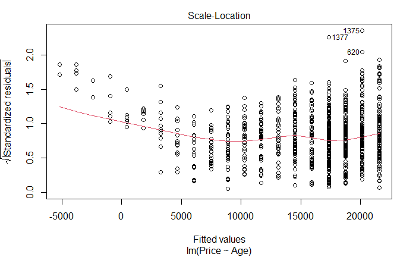

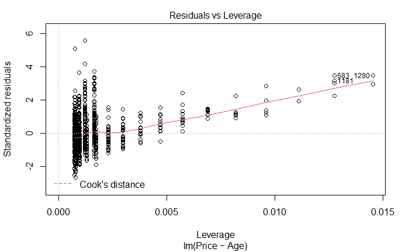

```r
plot(mod1)
```

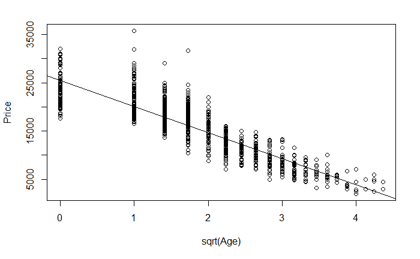

```r
# square root Age
plot(Price~sqrt(Age), data = MyCars)
abline(lm(Price~sqrt(Age), data = MyCars))
```

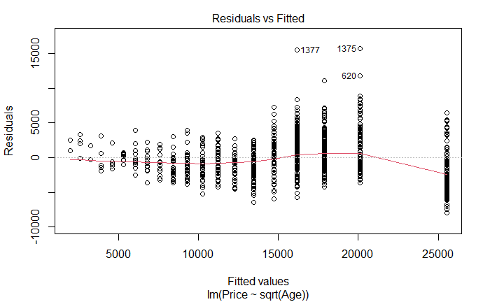

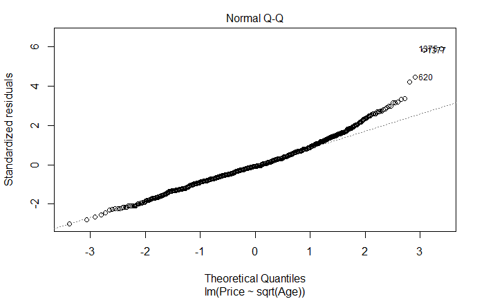

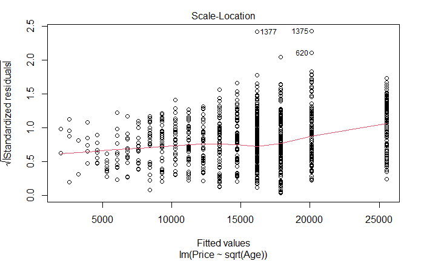

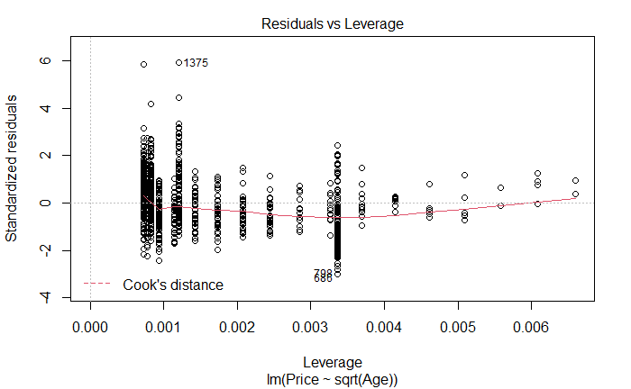

```r
plot(lm(Price~sqrt(Age), data = MyCars))
```

```r
hist(mod1$residuals)
```

[output not shown]

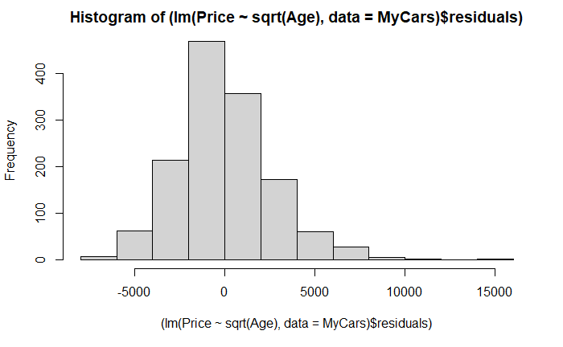

```r
hist((lm(Price~sqrt(Age), data = MyCars)$residuals))
```

```r
transformmod <- lm(Price~sqrt(Age), data = MyCars)
```

```r
# With square root age
B0.2 = summary(lm(Price~Age, MyCars))$coefficients[1,1] # Intercept
B1.2 = summary(lm(Price~Age, MyCars))$coefficients[2,1] # Slope

B0.2.trans = summary(lm(sqrt(Price)~Age, data = MyCars))$coefficients[1,1] # Intercept
B1.2.trans = summary(lm(sqrt(Price)~Age, data = MyCars))$coefficients[2,1] # Slope

plot(Price~Age, MyCars)
curve(B1.2*x+B0.2, col = "green", add=TRUE)
```

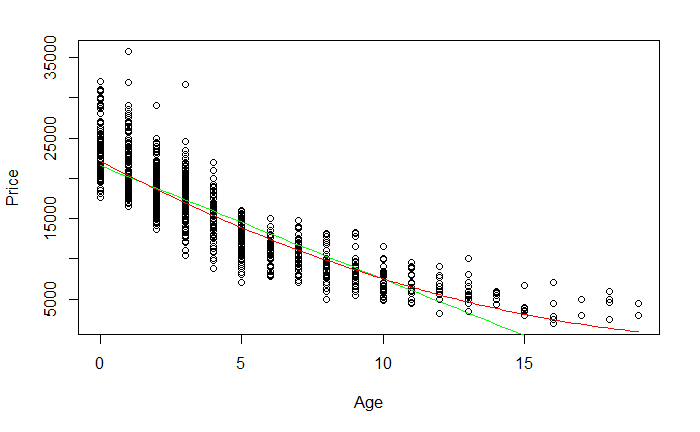

```r
curve((B1.2.trans*x+B0.2.trans)^2, col = "red", add=TRUE)
```

```r
# Trying with Log
B0.1 = summary(lm(Price~Age, MyCars))$coefficients[1,1] # Intercept
B1.1 = summary(lm(Price~Age, MyCars))$coefficients[2,1] # Slope

B0.1.trans = summary(lm(log(Price)~Age, data = MyCars))$coefficients[1,1] # Intercept
B1.1.trans = summary(lm(log(Price)~Age, data = MyCars))$coefficients[2,1] # Slope

plot(Price~Age, MyCars)
curve(B1.1*x+B0.1, col = "green", add=TRUE)
```

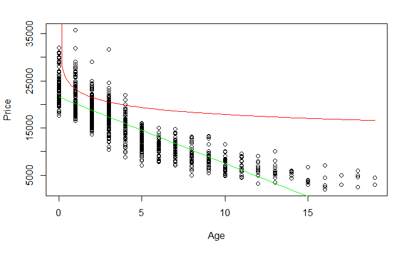

```r
curve(exp(B0.1.trans)*x^B1.1.trans, col = "red", add=TRUE)
```

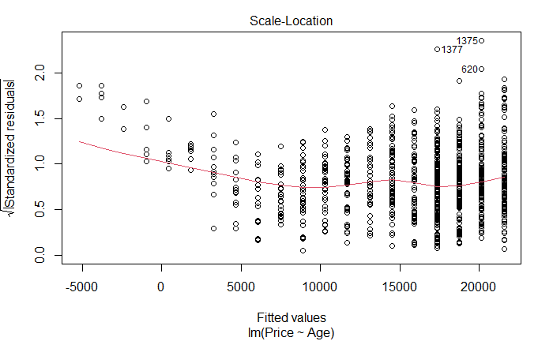

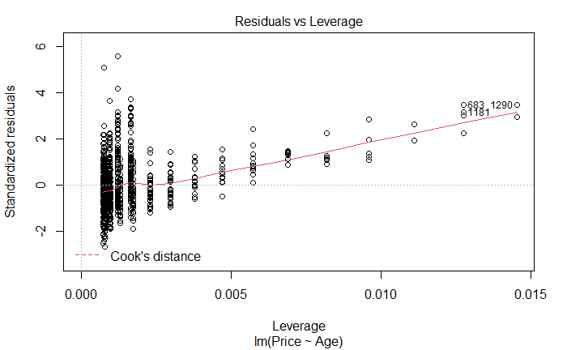

```r
#Original
plot(mod1)
```

```r
plot(Price~Age, data = MyCars) # This is the original
abline(lm(Price~Age, data = MyCars))
```

[output not shown]

```r
plot(lm(Price~Age, data = MyCars), 1:2)
```

[output not shown]

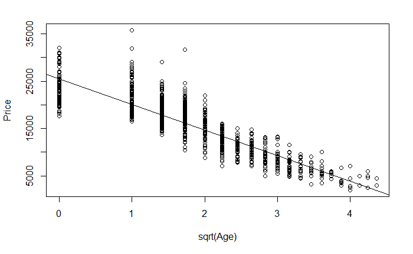

```r
# square root Age
plot(Price~sqrt(Age), data = MyCars)
abline(lm(Price~sqrt(Age), data = MyCars))
```

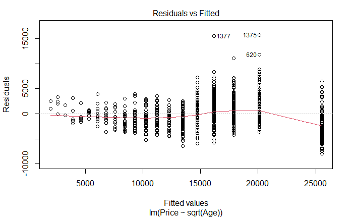

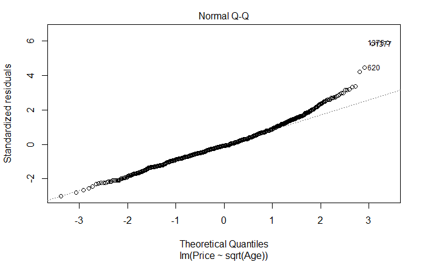

```r
plot(lm(Price~sqrt(Age), data = MyCars), 1:2)
```

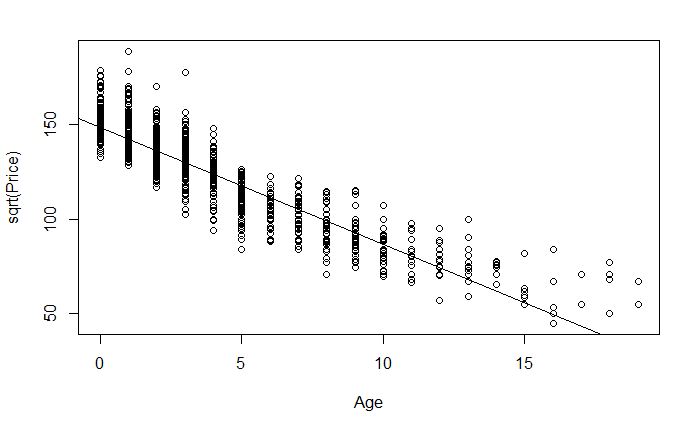

```r
# Square root Price
plot(sqrt(Price)~Age, data = MyCars)
abline(lm(sqrt(Price)~Age, data = MyCars))
```

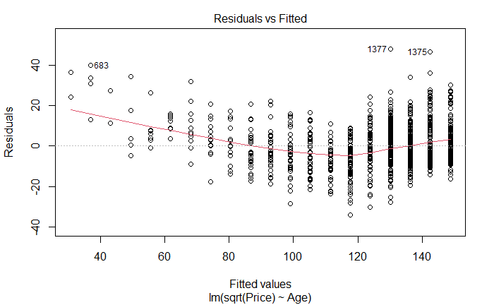

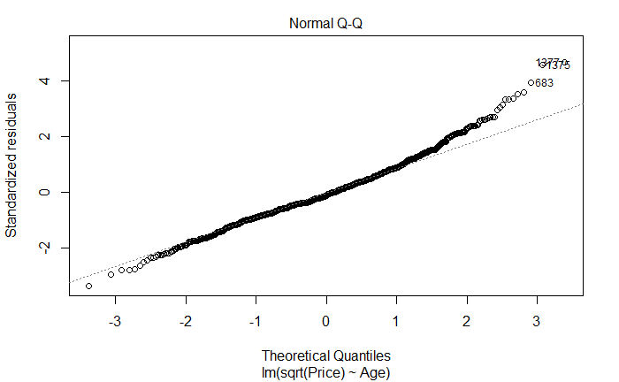

```r
plot(lm(sqrt(Price)~Age, data = MyCars), 1:2)
```

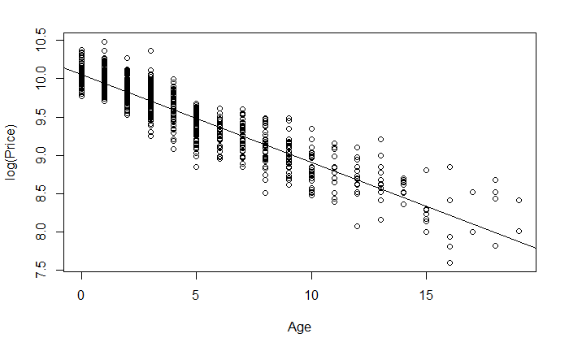

```r
# Log Price
plot(log(Price)~Age, data = MyCars)
abline(lm(log(Price)~Age, data = MyCars))
```

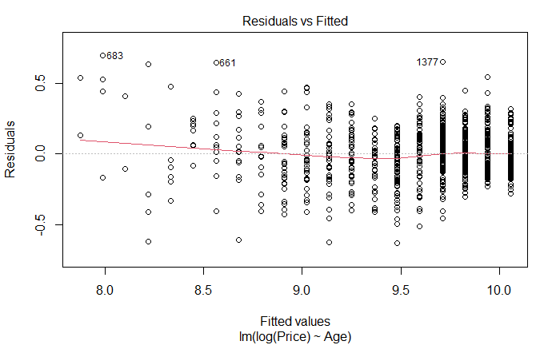

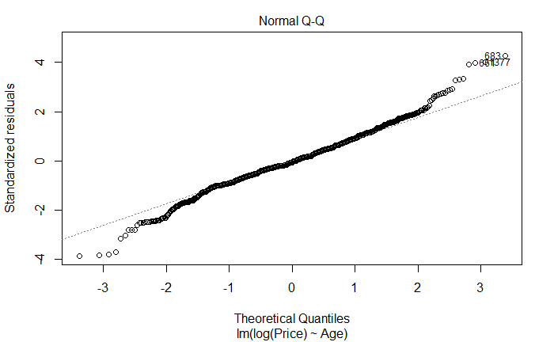

```r
plot(lm(log(Price)~Age, data = MyCars), 1:2)
```

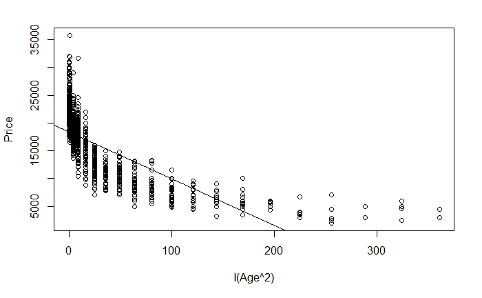

```r
# Add Exponent to Age
plot(Price~I(Age^2), data = MyCars)
abline(lm(Price~I(Age^2), data = MyCars))
```

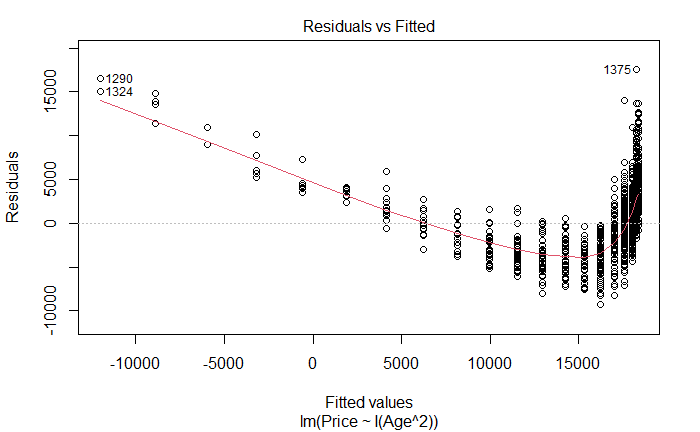

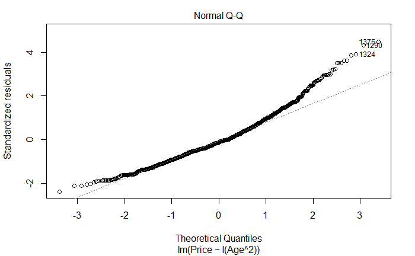

```r
plot(lm(Price~I(Age^2), data = MyCars), 1:2)
```

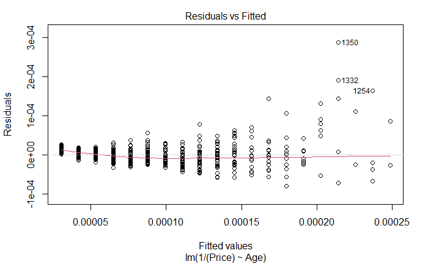

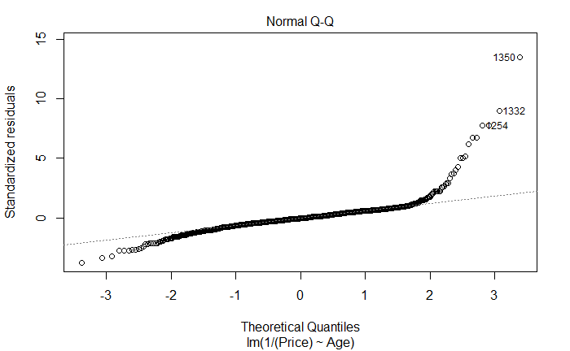

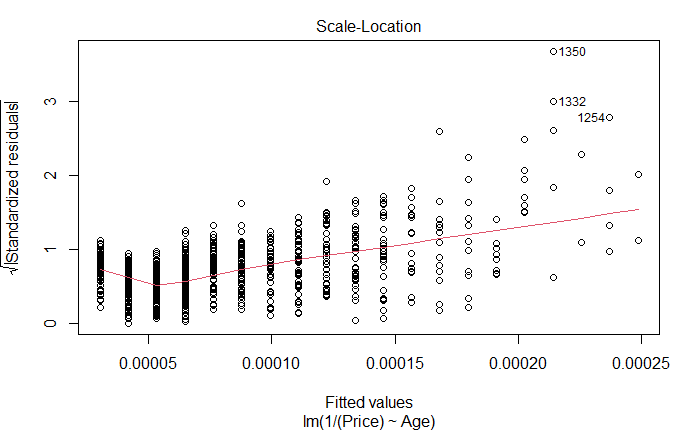

```r
# Division Price
plot(lm(1/(Price)~Age, data=MyCars))
```

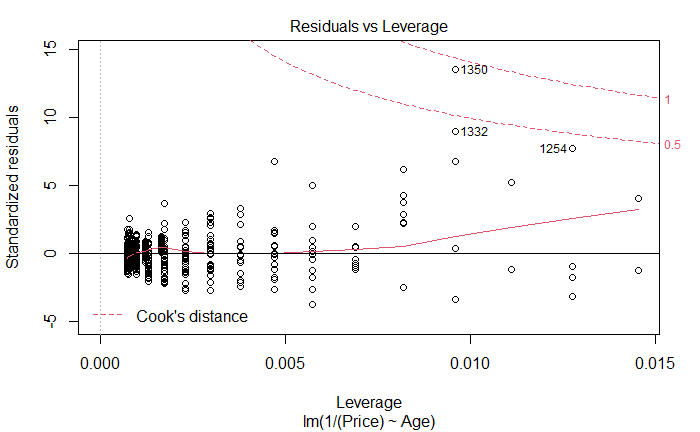

```r
abline(lm(1/(Price)~Age, data=MyCars))
```

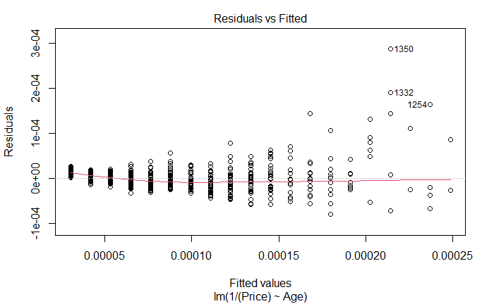

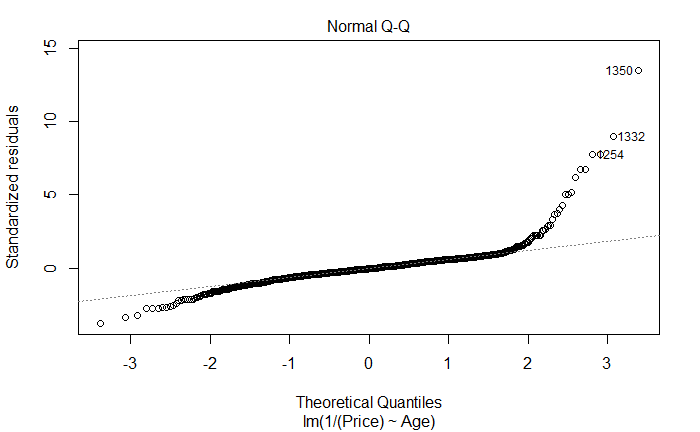

```r
plot(lm(1/(Price)~Age, data=MyCars), 1:2)
```

11. According to your transformed model, is there an age at which the car should be free? If so, find this age and comment on what the “free car” phenomenon says about the appropriateness of your model.

According to my model, when a car reaches 23.9 years old the car would be predicted as “free”. This free car phenomenon says that the model I chose may not be the best. This also means that I may need to add certain constraints to my model to ensure that it doesn’t reach zero. These constraints may be through the form of a different type of transformation or it may be through phyiscally coding into R a constraint that the model should not be able to achieve. I could do this by looking into the average baseline price for TX honda accords and write the constraint based on what the sample population looks like.

```r
#Free Car Age
# When y is zero, what is x
freecarage <- (sqrt(0)-B0.2.trans)/B1.2.trans
freecarage
```

```
[1] 23.93987
```

```r
B0.2 = summary(lm(Price~Age, MyCars))$coefficients[1,1] # Intercept
B1.2 = summary(lm(Price~Age, MyCars))$coefficients[2,1] # Slope

B0.2.trans = summary(lm(sqrt(Price)~Age, data = MyCars))$coefficients[1,1] # Intercept
B1.2.trans = summary(lm(sqrt(Price)~Age, data = MyCars))$coefficients[2,1] # Slope

plot(Price~Age, MyCars)
curve(B1.2*x+B0.2, col = "green", add=TRUE)
```

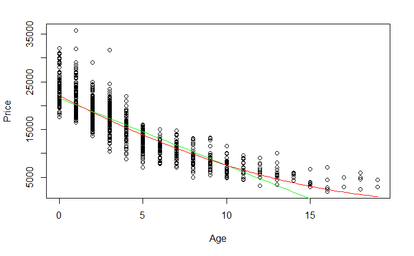

```r
curve((B1.2.trans*x+B0.2.trans)^2, col = "red", add=TRUE)
```

12. Again suppose that you are interested in purchasing a car of this model that is four years old (in 2017). Determine each of the following using your model constructed in question 9: 90% confidence interval for the mean price at this age and 90% prediction interval for the price of an individual car at this age. Write sentences that carefully interpret each of the intervals (in terms of car prices).

We are 90% confident that the true mean price of a single 4 year old honda accord in texas is between 10801.38 and 20711.64 dollars. We are 90% confident that the ture mean price of the sample population for 4 year old honda accords in texas is between 15223.54 and 15490.62 dollars.

```r
confint(lm(sqrt(Price)~Age, data = MyCars), level = 0.90)
```

```
                   5 %       95 %
(Intercept) 148.101008 149.462581
Age          -6.345354  -6.084272
```

```r
148.10^2
```

```
[1] 21933.61
```

```r
149.45^2
```

```
[1] 22335.3
```

```r
newx.2=data.frame(Age = 4)
head(newx.2)
```

|  | Age |
| --- | --- |
| 1 | 4 |

```r
predict.lm(lm(sqrt(Price)~Age, data = MyCars), newx.2, interval="confidence") # All peope; for poualtion
```

```
       fit      lwr      upr
1 123.9225 123.3837 124.4613
```

```r
123.3837^2
```

```
[1] 15223.54
```

```r
124.4613^2
```

```
[1] 15490.62
```

```r
predict.lm(lm(sqrt(Price)~Age, data = MyCars), newx.2, interval="prediction") #For one perosn
```

```
       fit      lwr      upr
1 123.9225 103.9297 143.9154
```

```r
103.9297^2
```

```
[1] 10801.38
```

```r
143.9154^2
```

```
[1] 20711.64
```

#### MODEL #2: Use Mileage as a predictor for Price

13. Calculate the least squares regression line that best fits your data (with *Mileage* now as the predictor) and produce a scatterplot of the relationship with the regression line on it.

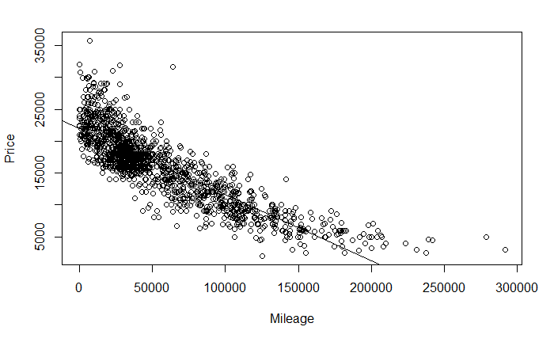

```r
mod3 <- lm(Price~Mileage, MyCars)
plot(Price~Mileage, MyCars)
abline(mod3)
```

```r
summary(mod3)
```

```
Call:
lm(formula = Price ~ Mileage, data = MyCars)

Residuals:
    Min      1Q  Median      3Q     Max
-8572.4 -1878.2  -365.7  1543.6 16294.9

Coefficients:
              Estimate Std. Error t value Pr(>|t|)
(Intercept)  2.200e+04  1.245e+02   176.7   <2e-16 ***
Mileage     -1.039e-01  1.694e-03   -61.3   <2e-16 ***
---
Signif. codes:  0 ‘***’ 0.001 ‘**’ 0.01 ‘*’ 0.05 ‘.’ 0.1 ‘ ’ 1

Residual standard error: 2916 on 1375 degrees of freedom
Multiple R-squared:  0.7321,    Adjusted R-squared:  0.7319
F-statistic:  3758 on 1 and 1375 DF,  p-value: < 2.2e-16
```

14. Produce appropriate residual plots and comment on how well your data appear to fit the conditions for a simple linear model. Don’t worry about doing transformations at this point if there are problems with the conditions.

Inspecting the five conditions for a simple linear model: - Linearity: This data does not fit the linear model very well. The simple linear model shows the data largely favoring the left side of the graph, while the fitted residuals plot shows the data heavily hugging the right side of the graph.  
- Zero mean: The histogram and fitted residuals appears to be centered around zero, but there is a definite skew towards the right.  
- COnstant Variance: The data is heavily clustered towards the left side of the graph. It spreads out slightly as you move more to the right, but not very much.  
- Independence: I will assume that each car is independent of each other. - Normality: Looking at the histogram of the residuals, this method appears to have a right skew. The qq-norm plot also suggests slight deviation from normality at the tails of the regression line.

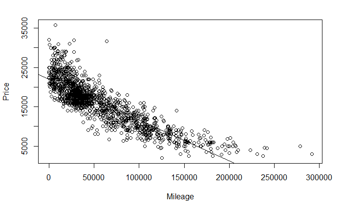

```r
plot(Price~Mileage, MyCars)
abline(mod3)
```

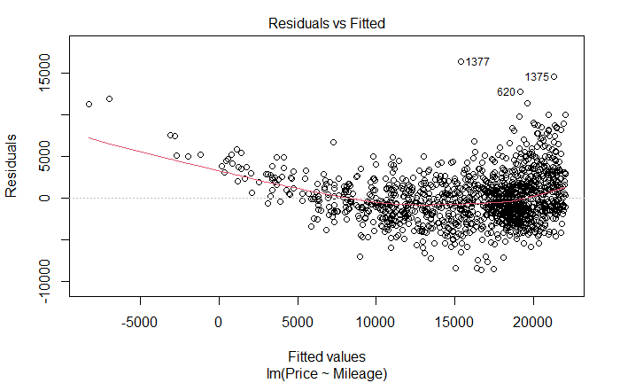

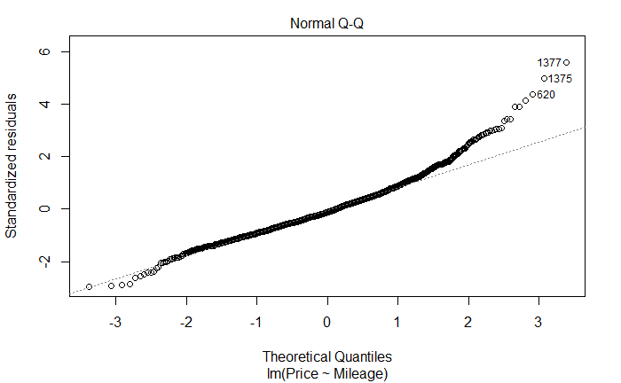

```r
plot(mod3, 1:2)
```

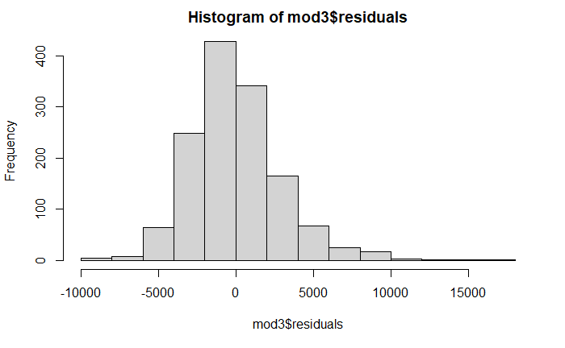

```r
hist(mod3$residuals)
```

15. Experiment with some transformations to attempt to find one that seems to do a better job of satisfying the linear model conditions. Include the summary output for fitting that model and a scatterplot of the original data with this new model (which is likely a curve on the original data). Explain why you think that this transformation does or does not improve satisfying the linear model conditions.

I think the linear model is the best to represent the regression for Price by car Mileage. If I was to choose a different approach, I think that the squareroot Price approach would be the second best. I think this due to the data conforming to many of the five conditions for a simple linear model:

- Linearity: The SLRL does not appear to fit the data as closely as the non-transformed simple linear model. Nonetheless, the data appears to follow it in a roughly linear progression, with a slight downwards curve as the graph progresses from left to right.
- Zero mean: The residuals vs fitted plot and the histogram are both centered around a zero mean.
- COnstant Variance: There is roughly constant variance. I think the transformed data has more data varation than the untransformed simple linear model because the transformed model conforms closer to a normal distribution than the untransformed simple linear model.
- Independence: I will assume that each car is independent of each other.
- Normality: Looking at the histogram of the residuals, this method appears to have a slight right skew. This is a better histogram than the un-transformed simple linear regression that mod3 represents. The qq-norm plot also hugs the line much closer than the simple linear model.

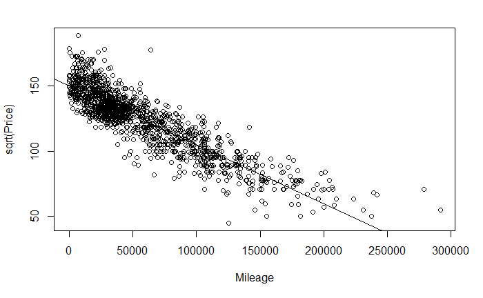

```r
mod4 <- lm(sqrt(Price)~Mileage, data = MyCars)
# Square root Price
plot(sqrt(Price)~Mileage, data = MyCars)
abline(mod4)
```

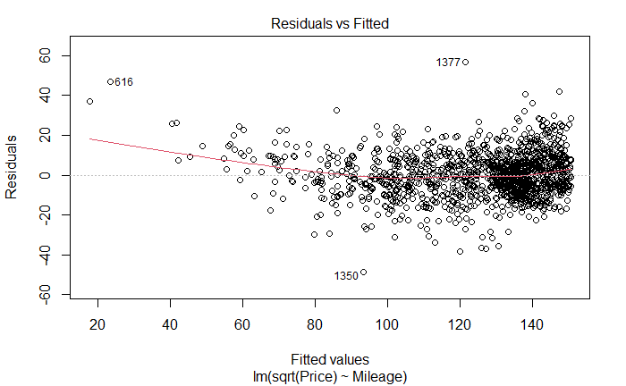

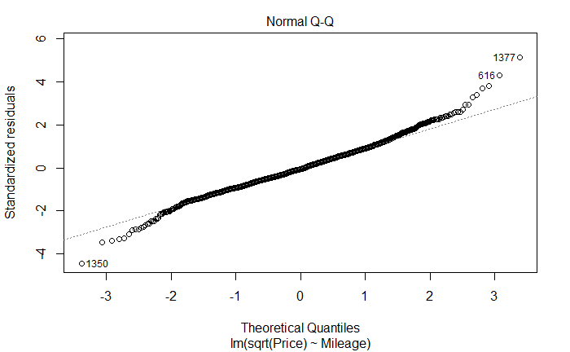

```r
plot(mod4, 1:2)
```

```r
summary(mod4)
```

```
Call:
lm(formula = sqrt(Price) ~ Mileage, data = MyCars)

Residuals:
    Min      1Q  Median      3Q     Max
-48.627  -6.885  -0.540   6.618  56.520

Coefficients:
              Estimate Std. Error t value Pr(>|t|)
(Intercept)  1.505e+02  4.693e-01  320.67   <2e-16 ***
Mileage     -4.552e-04  6.386e-06  -71.28   <2e-16 ***
---
Signif. codes:  0 ‘***’ 0.001 ‘**’ 0.01 ‘*’ 0.05 ‘.’ 0.1 ‘ ’ 1

Residual standard error: 10.99 on 1375 degrees of freedom
Multiple R-squared:  0.787, Adjusted R-squared:  0.7869
F-statistic:  5081 on 1 and 1375 DF,  p-value: < 2.2e-16
```

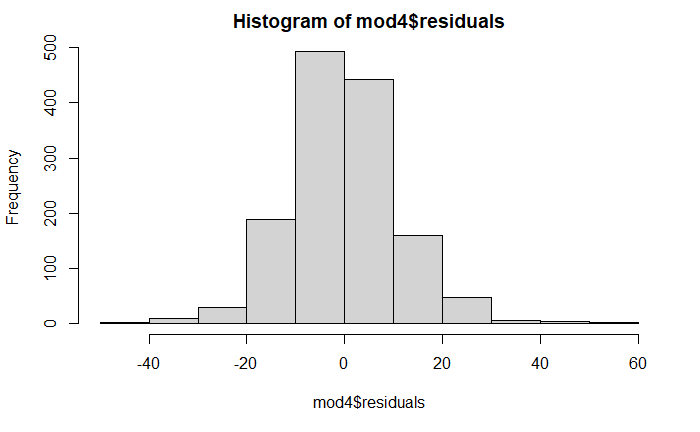

```r
hist(mod4$residuals)
```

```r
B0 = summary(lm(Price~Mileage, MyCars))$coefficients[1,1] # Intercept
B1 = summary(lm(Price~Mileage, MyCars))$coefficients[2,1] # Slope

B0.trans = summary(lm(sqrt(Price)~Mileage, data = MyCars))$coefficients[1,1] # Intercept
B1.trans = summary(lm(sqrt(Price)~Mileage, data = MyCars))$coefficients[2,1] # Slope
```

```r
plot(Price~Mileage, MyCars)
curve(B1*x+B0, col = "green", add=TRUE)
```

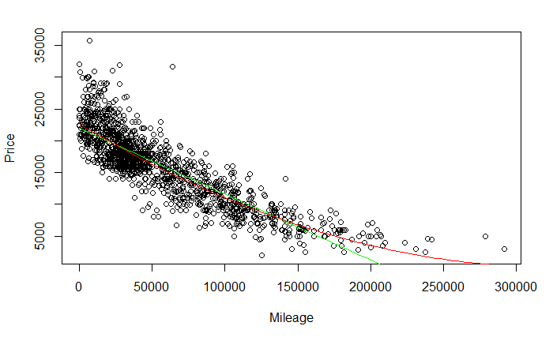

```r
curve((B1.trans*x+B0.trans)^2, col = "red", add=TRUE)
```

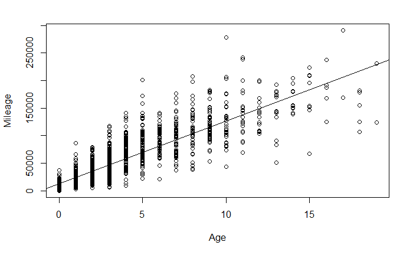

```r
plot(Mileage~Age, data = MyCars) # This is the original
abline(lm(Mileage~Age, data = MyCars))
```

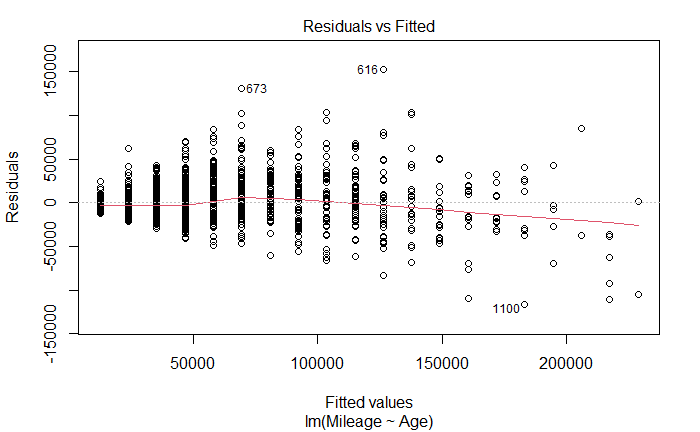

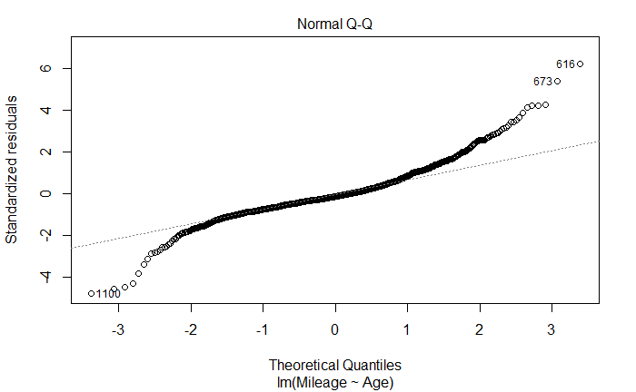

```r
plot(lm(Mileage~Age, data = MyCars), 1:2)
```

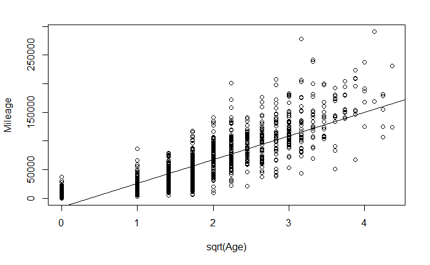

```r
# square root Age
plot(Mileage~sqrt(Age), data = MyCars)
abline(lm(Mileage~sqrt(Age), data = MyCars))
```

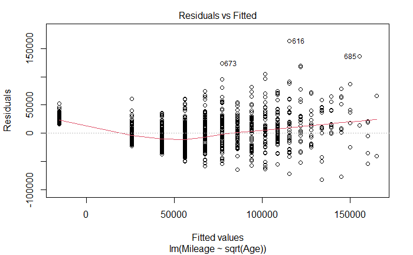

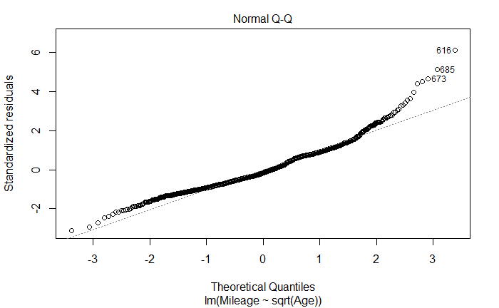

```r
plot(lm(Mileage~sqrt(Age), data = MyCars), 1:2)
```

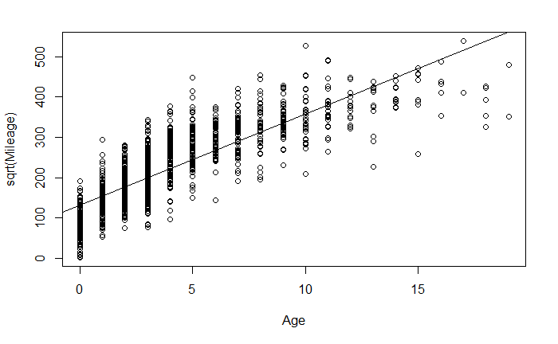

```r
# Square root Mileage
plot(sqrt(Mileage)~Age, data = MyCars)
abline(lm(sqrt(Mileage)~Age, data = MyCars))
```

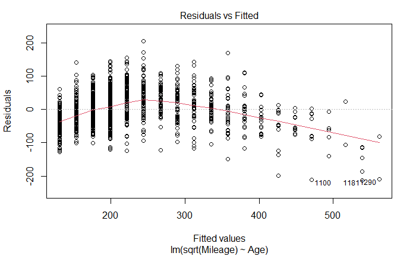

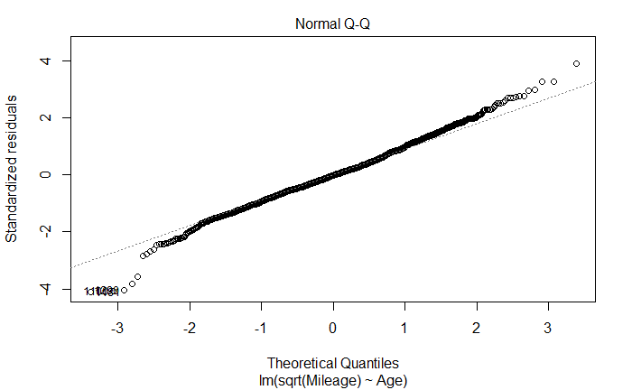

```r
plot(lm(sqrt(Mileage)~Age, data = MyCars), 1:2)
```

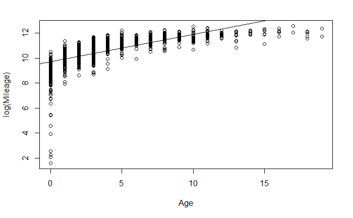

```r
# Log Mileage
plot(log(Mileage)~Age, data = MyCars)
abline(lm(log(Mileage)~Age, data = MyCars))
```

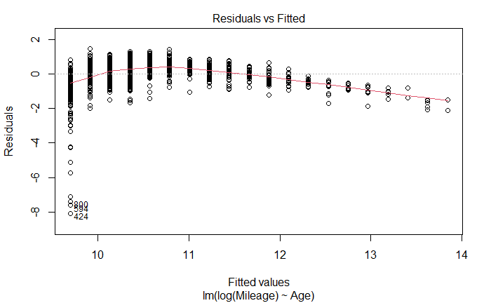

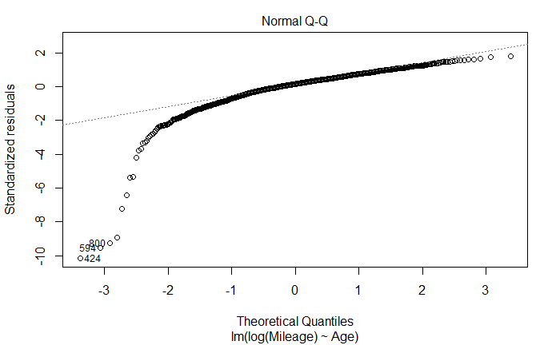

```r
plot(lm(log(Mileage)~Age, data = MyCars), 1:2)
```

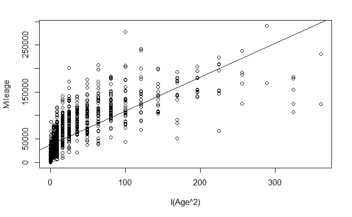

```r
# Add Exponent to Age
plot(Mileage~I(Age^2), data = MyCars)
abline(lm(Mileage~I(Age^2), data = MyCars))
```

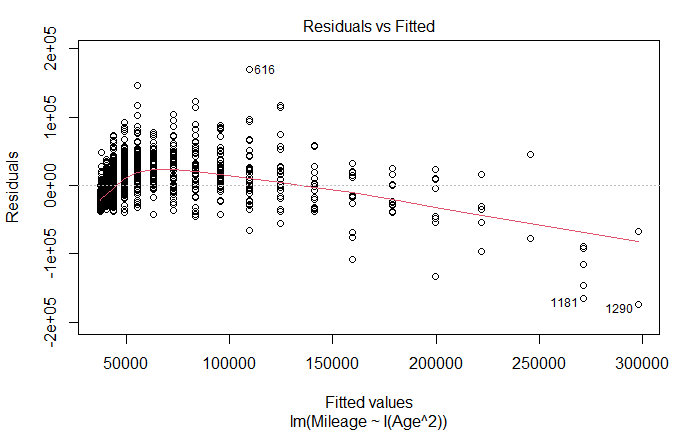

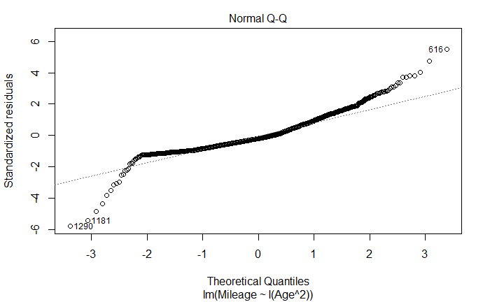

```r
plot(lm(Mileage~I(Age^2), data = MyCars), 1:2)
```

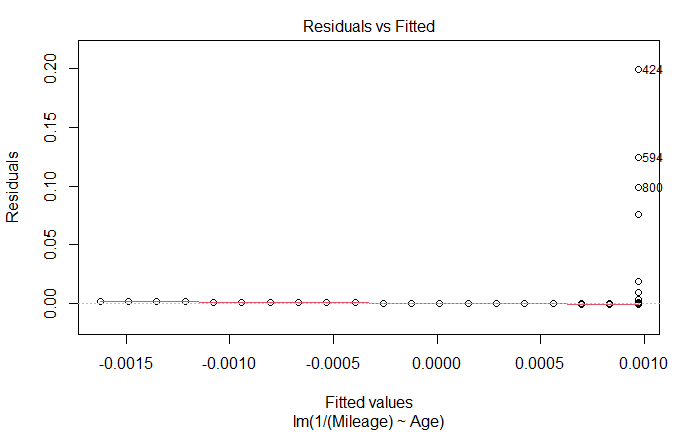

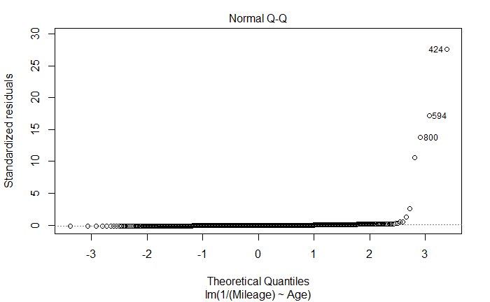

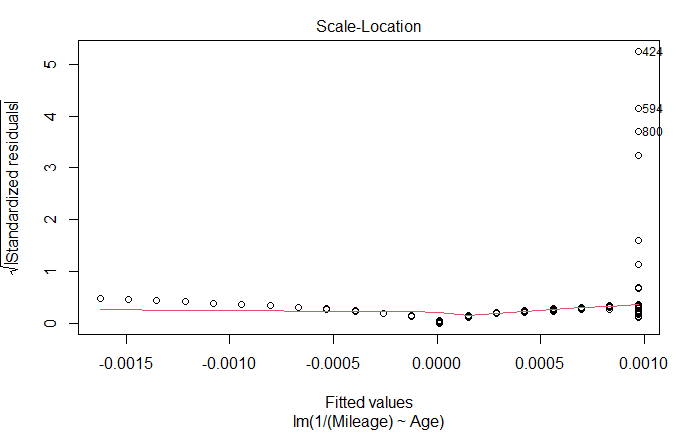

```r
# Division Mileage
plot(lm(1/(Mileage)~Age, data=MyCars))
```

[figure not shown]

```r
abline(lm(1/(Mileage)~Age, data=MyCars))
```

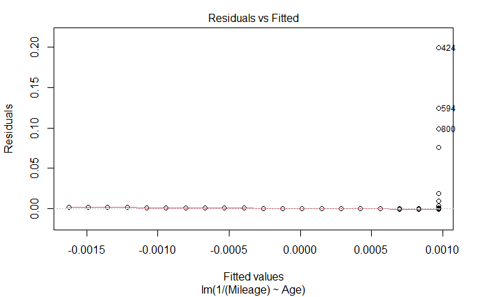

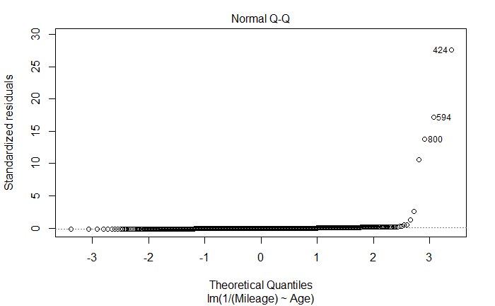

```r
plot(lm(1/(Mileage)~Age, data=MyCars), 1:2)
```

16. How do the models, using either *Age* or *Mileage* as the predictor compare? Does one of the models seem “better” or do they seem similar in their ability to predict *Price*? Explain.

```r
head(MyCars)
```

| Id | Price | Year | Mileage | City | State | Vin | Make | Model | Age | residuals |
| --- | --- | --- | --- | --- | --- | --- | --- | --- | --- | --- |
| 1476 | 21408 | 2017 | 4084 | Corpus Christi | TX | 1HGCR2F37HA181671 | Honda | Accord | 0 | -163.3519 |
| 1477 | 15995 | 2014 | 30914 | Houston | TX | 1HGCR2F31EA200629 | Honda | Accord | 3 | -1350.4184 |
| 1498 | 16997 | 2015 | 21028 | Fort Worth | TX | 1HGCR2F36FA256373 | Honda | Accord | 2 | -1757.0629 |
| 1521 | 15000 | 2014 | 47632 | McKinney | TX | 1HGCR2F32EA273248 | Honda | Accord | 3 | -2345.4184 |
| 1601 | 16000 | 2014 | 35785 | Frisco | TX | 1HGCR2F32EA254389 | Honda | Accord | 3 | -1345.4184 |
| 1629 | 17500 | 2014 | 27131 | San Antonio | TX | 1HGCR2F78EA204289 | Honda | Accord | 3 | 154.5816 |

```r
cor(MyCars[c(2,4,10)])
```

```
             Price    Mileage        Age
Price    1.0000000 -0.8556332 -0.8661308
Mileage -0.8556332  1.0000000  0.8494867
Age     -0.8661308  0.8494867  1.0000000
```

```r
cor.test(MyCars$Price, MyCars$Age)
```

```
    Pearson's product-moment correlation

data:  MyCars$Price and MyCars$Age
t = -64.257, df = 1375, p-value < 2.2e-16
alternative hypothesis: true correlation is not equal to 0
95 percent confidence interval:
 -0.8787504 -0.8523011
sample estimates:
       cor
-0.8661308
```

```r
cor.test(MyCars$Price, MyCars$Mileage)
```

```
    Pearson's product-moment correlation

data:  MyCars$Price and MyCars$Mileage
t = -61.3, df = 1375, p-value < 2.2e-16
alternative hypothesis: true correlation is not equal to 0
95 percent confidence interval:
 -0.8691730 -0.8408116
sample estimates:
       cor
-0.8556332
```

```r
anova(mod1)
```

```
Analysis of Variance Table

Response: Price
            Df     Sum Sq    Mean Sq F value    Pr(>F)
Age          1 3.2743e+10 3.2743e+10    4129 < 2.2e-16 ***
Residuals 1375 1.0904e+10 7.9300e+06
---
Signif. codes:  0 ‘***’ 0.001 ‘**’ 0.01 ‘*’ 0.05 ‘.’ 0.1 ‘ ’ 1
```

```r
anova(mod3)
```

```
Analysis of Variance Table

Response: Price
            Df     Sum Sq    Mean Sq F value    Pr(>F)
Mileage      1 3.1954e+10 3.1954e+10  3757.7 < 2.2e-16 ***
Residuals 1375 1.1693e+10 8.5038e+06
---
Signif. codes:  0 ‘***’ 0.001 ‘**’ 0.01 ‘*’ 0.05 ‘.’ 0.1 ‘ ’ 1
```

```r
hist(mod1$residuals)
```

[output not shown]

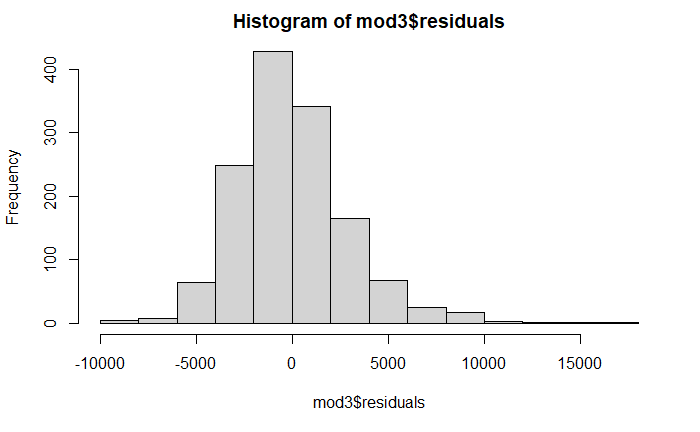

```r
hist(mod3$residuals)
```